# Exploratory Data Analysis of the Red Wine Quality Dataset by *Tianzhixi Yin*

```
##   X fixed.acidity volatile.acidity citric.acid residual.sugar chlorides
## 1 1           7.4             0.70        0.00            1.9     0.076
## 2 2           7.8             0.88        0.00            2.6     0.098
## 3 3           7.8             0.76        0.04            2.3     0.092
## 4 4          11.2             0.28        0.56            1.9     0.075
## 5 5           7.4             0.70        0.00            1.9     0.076
## 6 6           7.4             0.66        0.00            1.8     0.075
##   free.sulfur.dioxide total.sulfur.dioxide density   pH sulphates alcohol
## 1                  11                   34  0.9978 3.51      0.56     9.4
## 2                  25                   67  0.9968 3.20      0.68     9.8
## 3                  15                   54  0.9970 3.26      0.65     9.8
## 4                  17                   60  0.9980 3.16      0.58     9.8
## 5                  11                   34  0.9978 3.51      0.56     9.4
## 6                  13                   40  0.9978 3.51      0.56     9.4
##   quality
## 1       5
## 2       5
## 3       5
## 4       6
## 5       5
## 6       5
```

The first column of the original data is just the row number. I do not want to include it in the analysis so I remove it.

# Univariate Plots Section

```
## [1] 1599   12
```

```
##  [1] "fixed.acidity"        "volatile.acidity"     "citric.acid"
##  [4] "residual.sugar"       "chlorides"            "free.sulfur.dioxide"
##  [7] "total.sulfur.dioxide" "density"              "pH"
## [10] "sulphates"            "alcohol"              "quality"
```

```
## 'data.frame':    1599 obs. of  12 variables:
##  $ fixed.acidity       : num  7.4 7.8 7.8 11.2 7.4 7.4 7.9 7.3 7.8 7.5 ...
##  $ volatile.acidity    : num  0.7 0.88 0.76 0.28 0.7 0.66 0.6 0.65 0.58 0.5 ...
##  $ citric.acid         : num  0 0 0.04 0.56 0 0 0.06 0 0.02 0.36 ...
##  $ residual.sugar      : num  1.9 2.6 2.3 1.9 1.9 1.8 1.6 1.2 2 6.1 ...
##  $ chlorides           : num  0.076 0.098 0.092 0.075 0.076 0.075 0.069 0.065 0.073 0.071 ...
##  $ free.sulfur.dioxide : num  11 25 15 17 11 13 15 15 9 17 ...
##  $ total.sulfur.dioxide: num  34 67 54 60 34 40 59 21 18 102 ...
##  $ density             : num  0.998 0.997 0.997 0.998 0.998 ...
##  $ pH                  : num  3.51 3.2 3.26 3.16 3.51 3.51 3.3 3.39 3.36 3.35 ...
##  $ sulphates           : num  0.56 0.68 0.65 0.58 0.56 0.56 0.46 0.47 0.57 0.8 ...
##  $ alcohol             : num  9.4 9.8 9.8 9.8 9.4 9.4 9.4 10 9.5 10.5 ...
##  $ quality             : int  5 5 5 6 5 5 5 7 7 5 ...
```

I think *quality* variable should be converted from integer to ordered factor for the modeling stage, because I do not think the integer values represent exactly the quality of the wine. However, for the exploratory analysis part, keeping it as integer is more convenient for plotting.

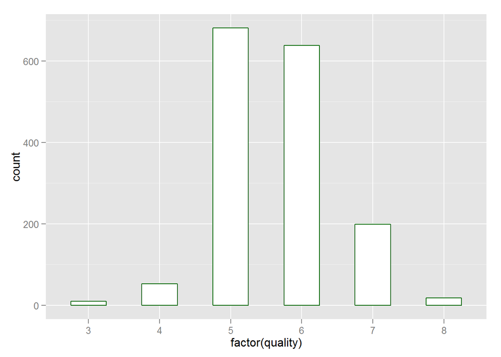

```
##    Min. 1st Qu.  Median    Mean 3rd Qu.    Max.
##   3.000   5.000   6.000   5.636   6.000   8.000
```

This is a histogram of *quality*, we can see most wines are of medium quality, the mean rating is 5.636.

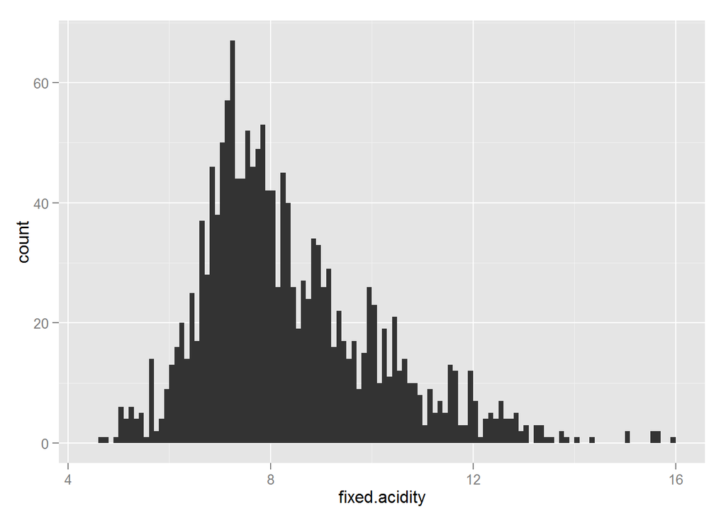

```
##    Min. 1st Qu.  Median    Mean 3rd Qu.    Max.
##    4.60    7.10    7.90    8.32    9.20   15.90
```

This is a histogram of *fixed.acidity*, quite obviously a normal distribution with a right tail, some outliers are at the end of the tail. The median is 7.90 while the greatest value is 15.90.

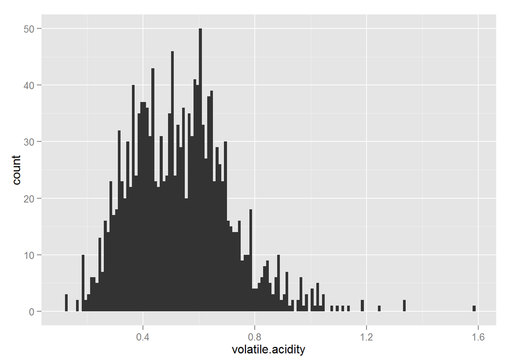

```
##    Min. 1st Qu.  Median    Mean 3rd Qu.    Max.
##  0.1200  0.3900  0.5200  0.5278  0.6400  1.5800
```

This is a histogram of *volatile.acidity*, it also follows a normal distribution with a long right tail, some outliers are at the end of the tail. The median is 0.52 while the greatest value is 1.58.

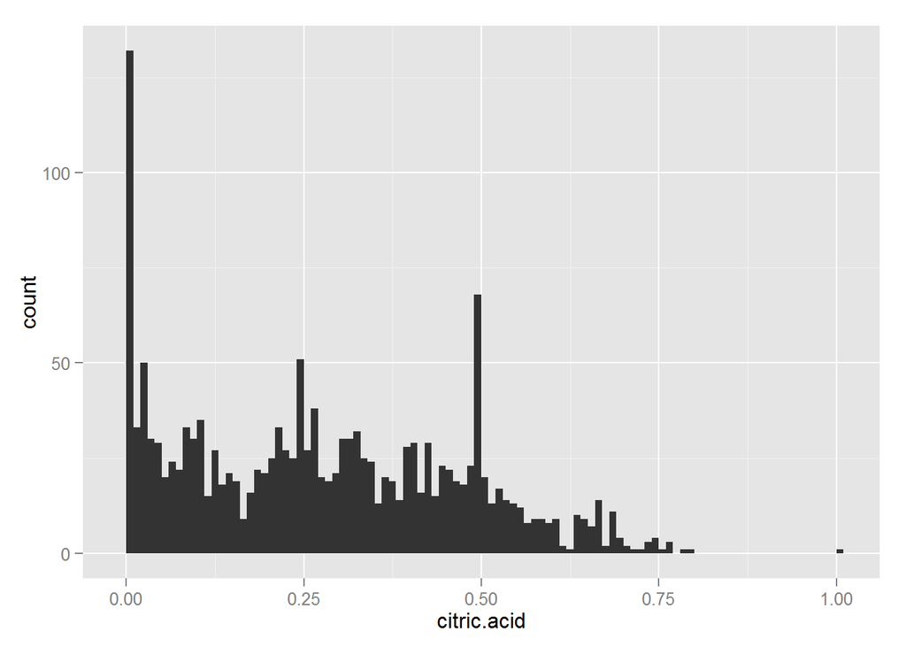

```
##    Min. 1st Qu.  Median    Mean 3rd Qu.    Max.
##   0.000   0.090   0.260   0.271   0.420   1.000
```

This is a histogram of *citric.acid*, it seemingly follows a Poisson distribution, an obvious outlier with value 1.

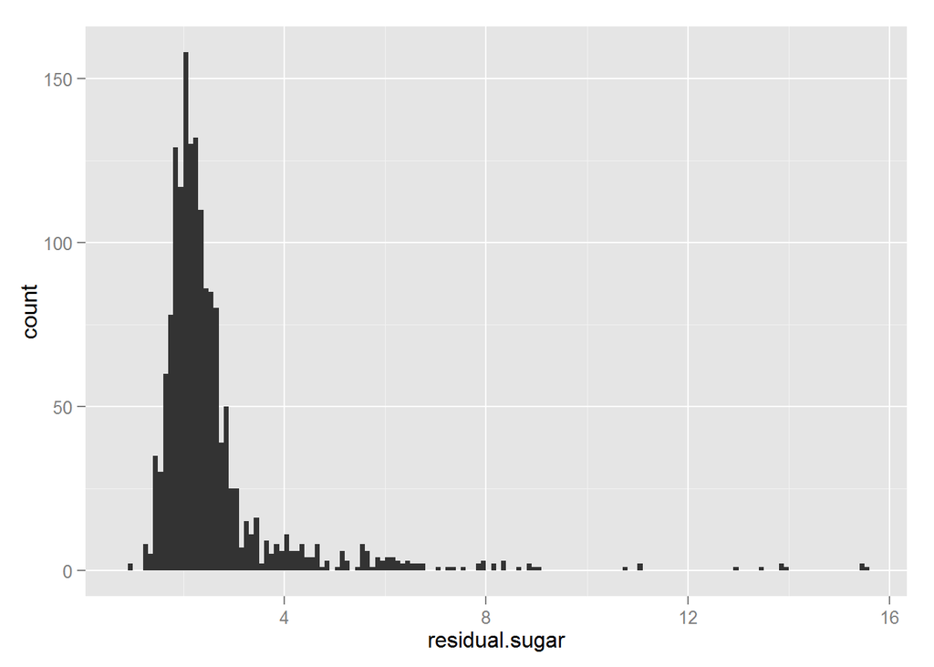

```
##    Min. 1st Qu.  Median    Mean 3rd Qu.    Max.
##   0.900   1.900   2.200   2.539   2.600  15.500
```

This is a histogram of *residual.sugar*, a normal distribution with a very long right tail, some outliers on the right. The median is 2.2 while the greatest value is 15.5.

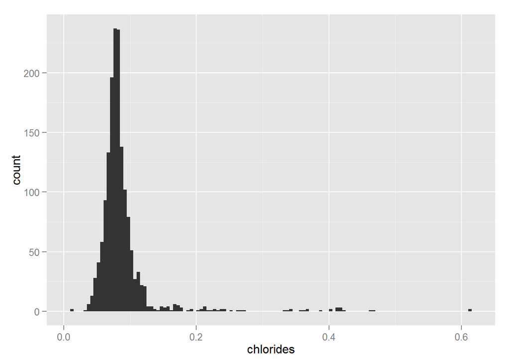

```
##    Min. 1st Qu.  Median    Mean 3rd Qu.    Max.
## 0.01200 0.07000 0.07900 0.08747 0.09000 0.61100
```

This is a histogram of *chlorides*, also an obvious bell-shaped distribution and a very long right tail, some outliers on the right. The median is 0.079 while the greatest value is 0.611.

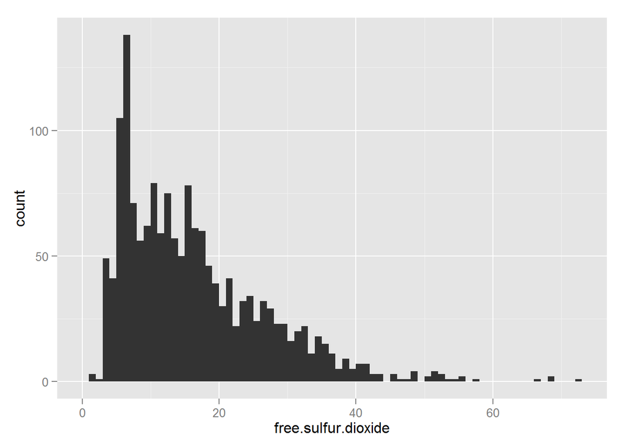

```
##    Min. 1st Qu.  Median    Mean 3rd Qu.    Max.
##    1.00    7.00   14.00   15.87   21.00   72.00
```

This is a histogram of *free.sulfur.dioxide*, it follows a Poisson distribution, some outliers at the right end.

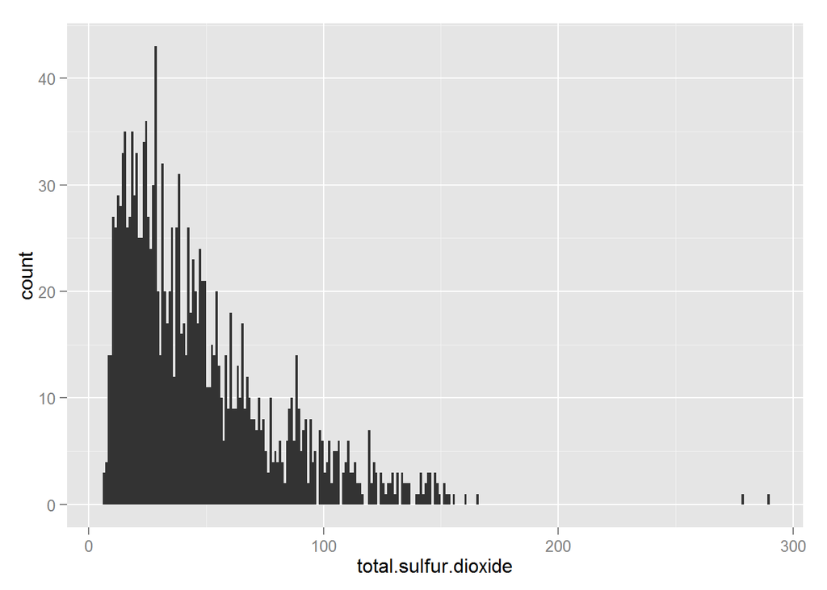

```
##    Min. 1st Qu.  Median    Mean 3rd Qu.    Max.
##    6.00   22.00   38.00   46.47   62.00  289.00
```

This is a histogram of *total.sulfur.dioxide*, it follows a Poisson distribution, few obvious outliers around 280.

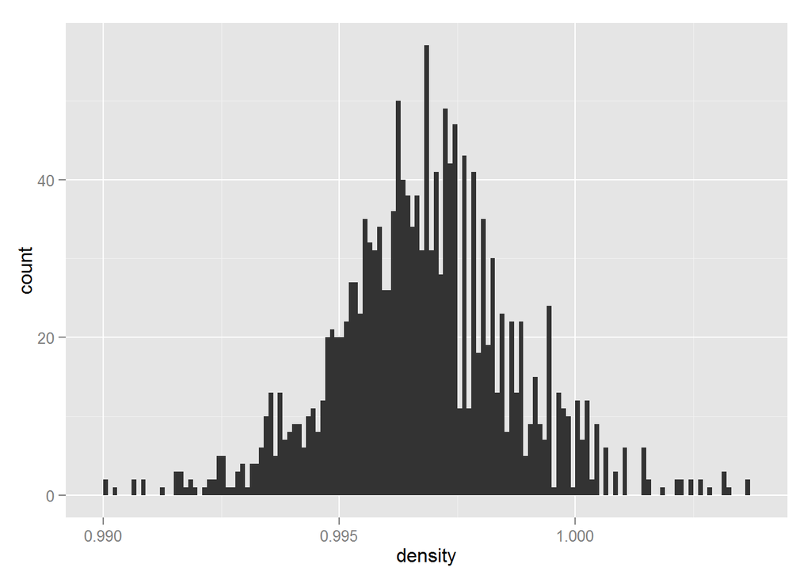

```
##    Min. 1st Qu.  Median    Mean 3rd Qu.    Max.
##  0.9901  0.9956  0.9968  0.9967  0.9978  1.0040
```

This is a histogram of *density*, clearly a normal distribution, no obvious outliers.

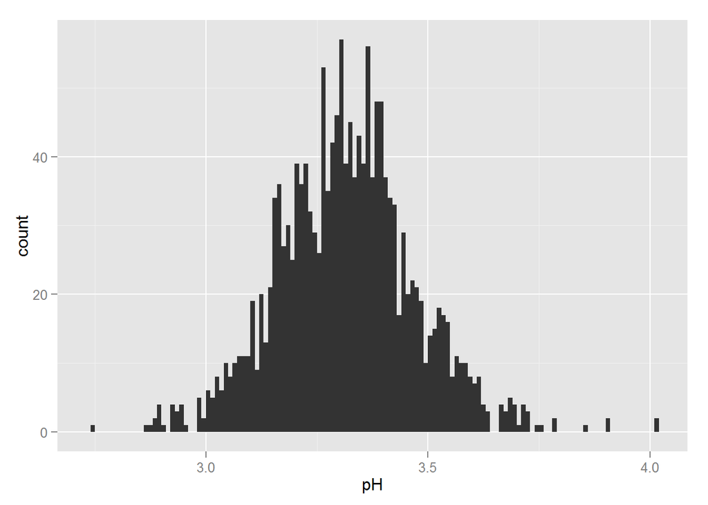

```
##    Min. 1st Qu.  Median    Mean 3rd Qu.    Max.
##   2.740   3.210   3.310   3.311   3.400   4.010
```

This is a histogram of *pH*, clearly a normal distribution, a few outliers at the right end.

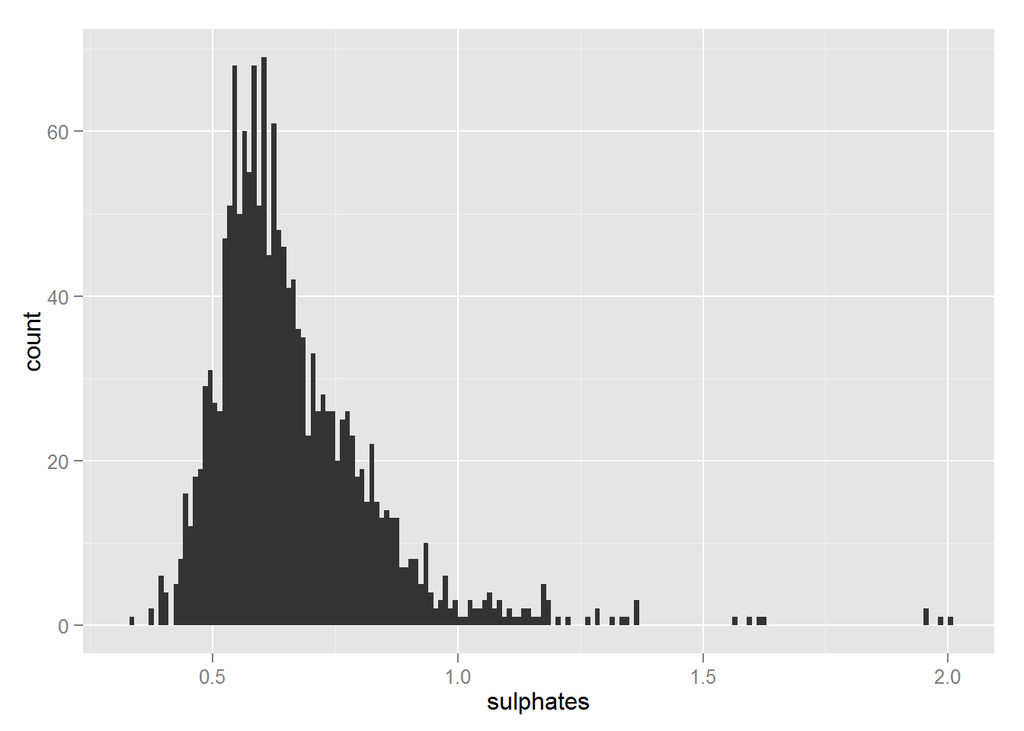

```
##    Min. 1st Qu.  Median    Mean 3rd Qu.    Max.
##  0.3300  0.5500  0.6200  0.6581  0.7300  2.0000
```

This is a histogram of *sulphates*, obviously bell-shaped, a very long right tail, some outliers on the right. The median is 0.62 while the greatest value is 2.

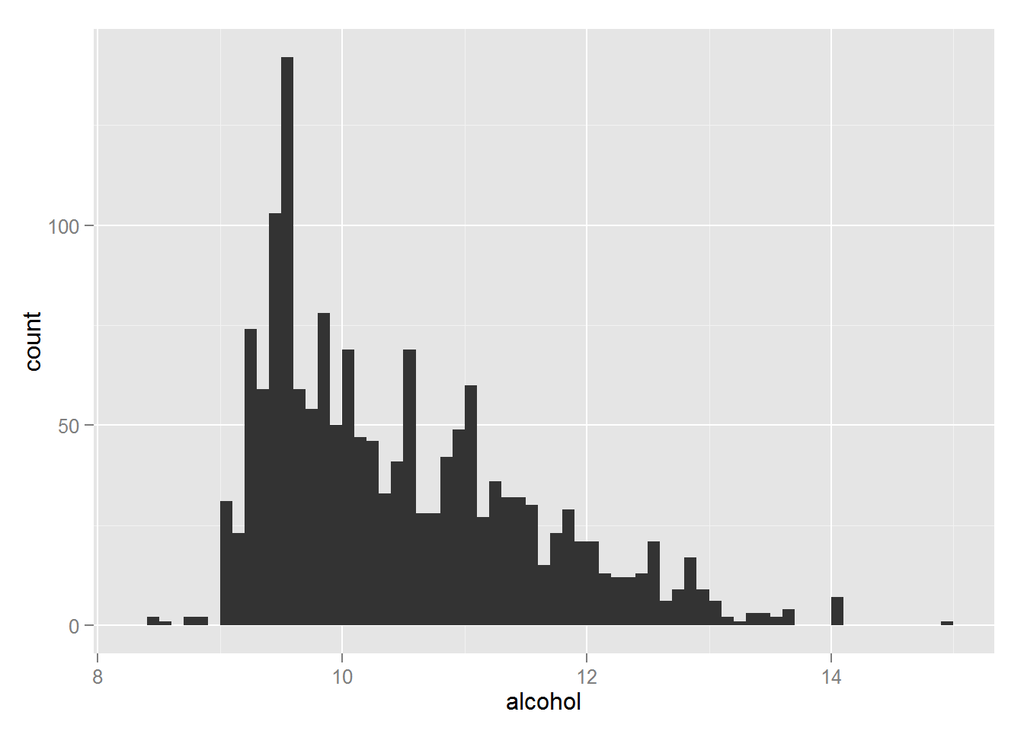

```
##    Min. 1st Qu.  Median    Mean 3rd Qu.    Max.
##    8.40    9.50   10.20   10.42   11.10   14.90
```

This is a histogram of *alcohol*, it follows a Poisson distribution.

Most wines are of medium quality. Some variables are obviously normally distributed (*density*, *pH*), maybe with a long tail (*fixed.acidity*, *volatile.acidity*, *residual.sugar*, *chlorides*, *sulphates*). Some variables seemingly follow a Poisson distribution (*citric.acid*, *free.sulfur.dioxide*, *total.sulfur.dioxide*, *alcohol*).

# Univariate Analysis

### What is the structure of your dataset?

There are 1,599 wines in the dataset with 12 features (*fixed.acidity*, *volatile.acidity*, *citric.acid*, *residual.sugar*, *chlorides*, *free.sulfur.dioxide*, *total.sulfur.dioxide*, *density*, *pH*, *sulphates*, *alcohol*, and *quality*). The wine quality is categorical with the following levels.

(worst) —————-> (best)

**quality**: 3, 4, 5, 6, 7, 8

Other observations: Only *quality* variable is categorical, all the explanatory variables are continuous.

The mean *quality* rate is 5.636.

The magnitudes of explanatory variables vary a lot. *total.sulfur.dioxide* goes from 6 to 289, *free.sulfur.dioxide* goes from 1 to 72, *fixed.acidity* and *alcohol* are aound 10, most of *volatile.acidity*, *citric.acid*, *chlorides*, *density*, and *sulphates* are under 1.

Also, from the histograms I observe some outliers in each variable. For example, *fixed.acidity* has some observations around 15 while the majority of observations are around 8, *volatile.acidity* of some wine are almost 1.6, which is much higher than the ordinary cases. Similar situations for *residual.sugar*, *chlorides*, and *sulphates* when we observe the long right tails while the majority of observations are bell-shaped. Also, for the seemingly Poisson ones, there are some high values with a small probability.

### What is/are the main feature(s) of interest in your dataset?

The main feature of interest is of course the *quality*, and I would like to see what features affect the *quality* more than others.

### What other features in the dataset do you think will help support your investigation into your feature(s) of interest?

Frankly, I am not acquainted with wine so I do not know what features are supposed to influence the *quality* significantly. My guess is that *density*, *pH*, and *alcohol* might play an important role in the taste. Hope that I can tell if my guess is correct after studying the dataset.

### Did you create any new variables from existing variables in the dataset?

No, but I want to transform the *quality* variable from interger to ordered factor for the modeling process (not for EDA now). I think the difference between ratings should not be measured exactly by these integers.

### Of the features you investigated, were there any unusual distributions? Did you perform any operations on the data to tidy, adjust, or change the form of the data? If so, why did you do this?

I did not find distributions so unusual that should raise concerns, so I did not perform any operations on the data.

# Bivariate Plots Section

```
##                      fixed.acidity volatile.acidity citric.acid
## fixed.acidity                1.000           -0.256       0.672
## volatile.acidity            -0.256            1.000      -0.552
## citric.acid                  0.672           -0.552       1.000
## residual.sugar               0.115            0.002       0.144
## chlorides                    0.094            0.061       0.204
## free.sulfur.dioxide         -0.154           -0.011      -0.061
## total.sulfur.dioxide        -0.113            0.076       0.036
## density                      0.668            0.022       0.365
## pH                          -0.683            0.235      -0.542
## sulphates                    0.183           -0.261       0.313
## alcohol                     -0.062           -0.202       0.110
## quality                      0.124           -0.391       0.226
##                      residual.sugar chlorides free.sulfur.dioxide
## fixed.acidity                 0.115     0.094              -0.154
## volatile.acidity              0.002     0.061              -0.011
## citric.acid                   0.144     0.204              -0.061
## residual.sugar                1.000     0.056               0.187
## chlorides                     0.056     1.000               0.006
## free.sulfur.dioxide           0.187     0.006               1.000
## total.sulfur.dioxide          0.203     0.047               0.668
## density                       0.355     0.201              -0.022
## pH                           -0.086    -0.265               0.070
## sulphates                     0.006     0.371               0.052
## alcohol                       0.042    -0.221              -0.069
## quality                       0.014    -0.129              -0.051
##                      total.sulfur.dioxide density     pH sulphates alcohol
## fixed.acidity                      -0.113   0.668 -0.683     0.183  -0.062
## volatile.acidity                    0.076   0.022  0.235    -0.261  -0.202
## citric.acid                         0.036   0.365 -0.542     0.313   0.110
## residual.sugar                      0.203   0.355 -0.086     0.006   0.042
## chlorides                           0.047   0.201 -0.265     0.371  -0.221
## free.sulfur.dioxide                 0.668  -0.022  0.070     0.052  -0.069
## total.sulfur.dioxide                1.000   0.071 -0.066     0.043  -0.206
## density                             0.071   1.000 -0.342     0.149  -0.496
## pH                                 -0.066  -0.342  1.000    -0.197   0.206
## sulphates                           0.043   0.149 -0.197     1.000   0.094
## alcohol                            -0.206  -0.496  0.206     0.094   1.000
## quality                            -0.185  -0.175 -0.058     0.251   0.476
##                      quality
## fixed.acidity          0.124
## volatile.acidity      -0.391
## citric.acid            0.226
## residual.sugar         0.014
## chlorides             -0.129
## free.sulfur.dioxide   -0.051
## total.sulfur.dioxide  -0.185
## density               -0.175
## pH                    -0.058
## sulphates              0.251
## alcohol                0.476
## quality                1.000
```

Since *alcohol* and *volatile.acidity* have the highest absolute correlation values with *quality* (0.476 and 0.391), I decide to plot their relationships. Below is a chart depicting the relationship between *quality* and *alcohol*. We can see high *alcohol* value generally leads to higher *quality* rating.

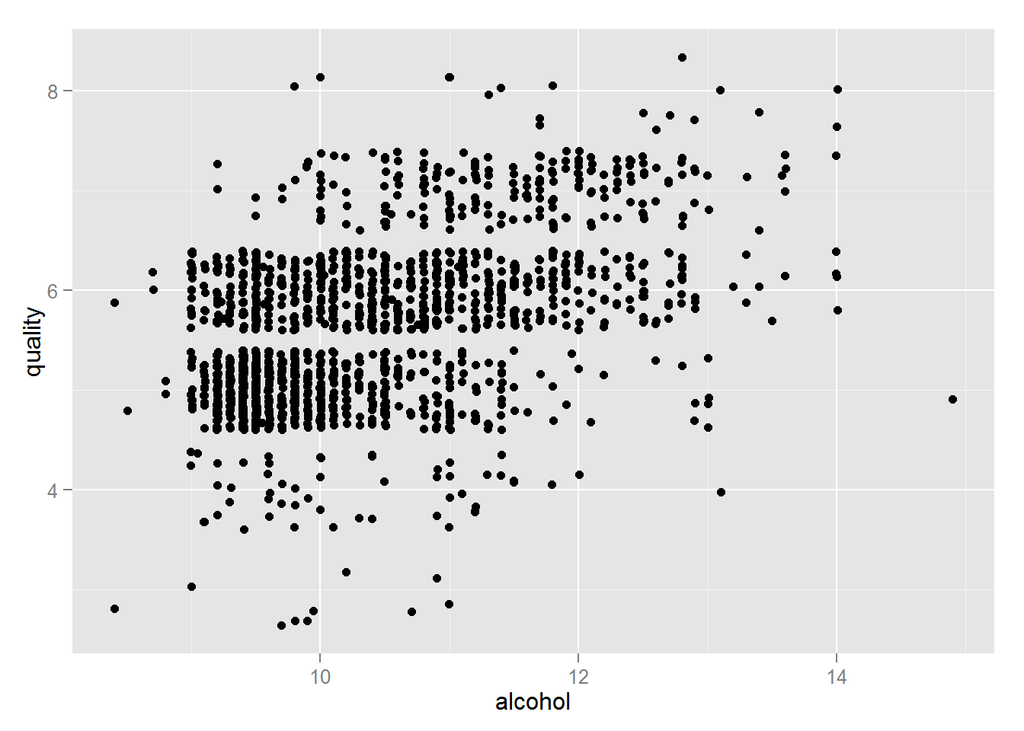

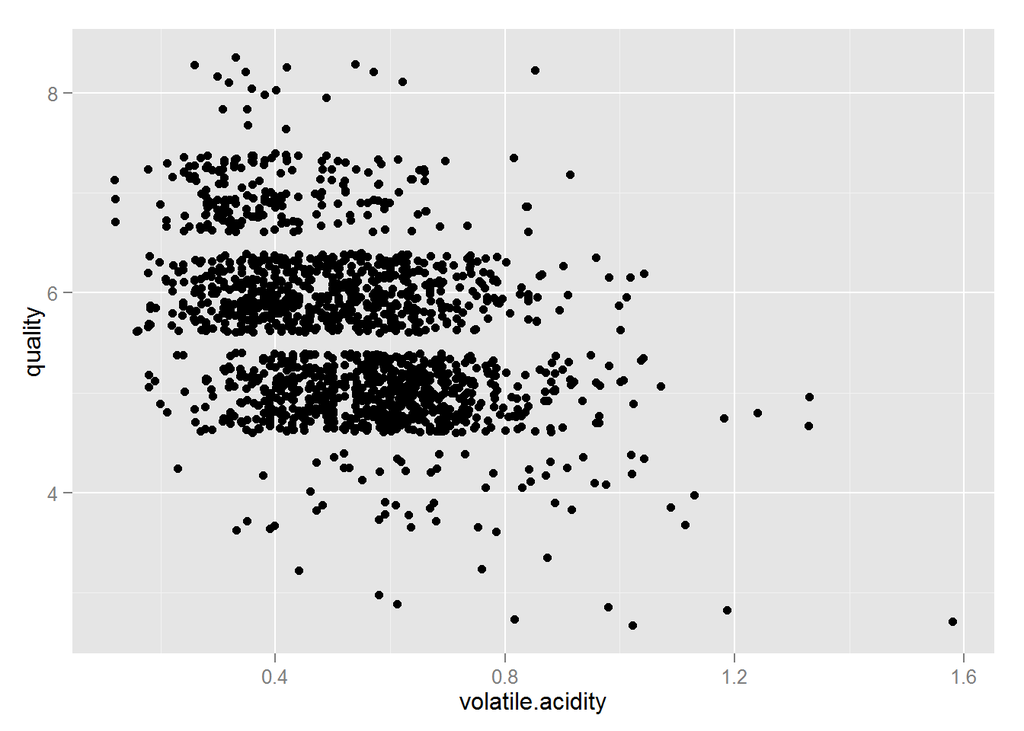

This is a chart depicting the relationship between *quality* and *volatile.acidity*. We can see low *volatile.acidity* value generally leads to higher *quality* rating.

Another way of looking at the relationships between *quality* and *alcohol*, *volatile.acidity* by boxplot.

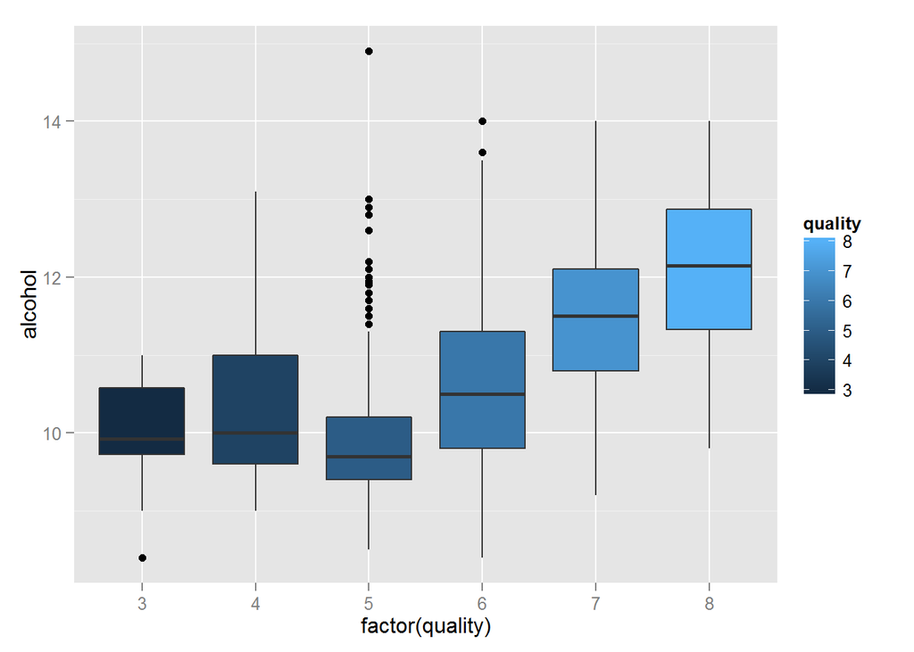

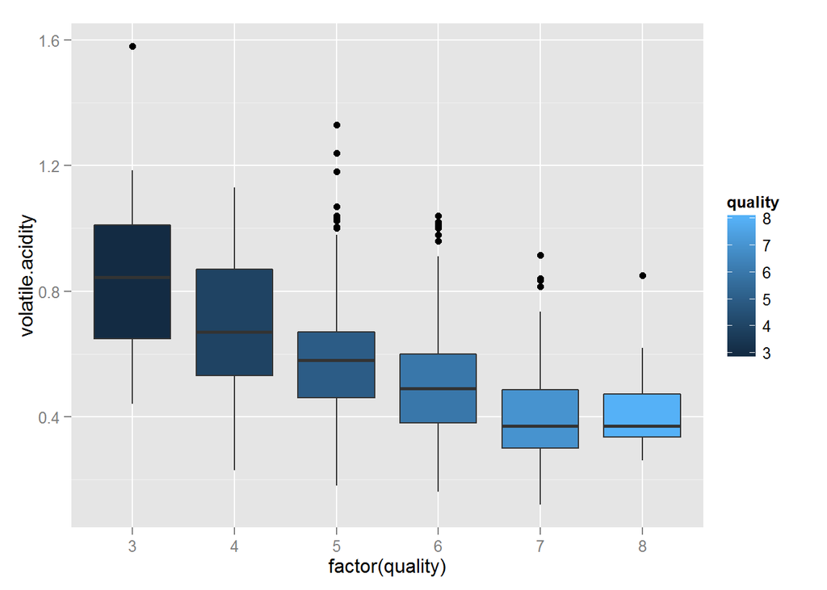

I try to find if there are other interesting relationships between *quality* and other features.

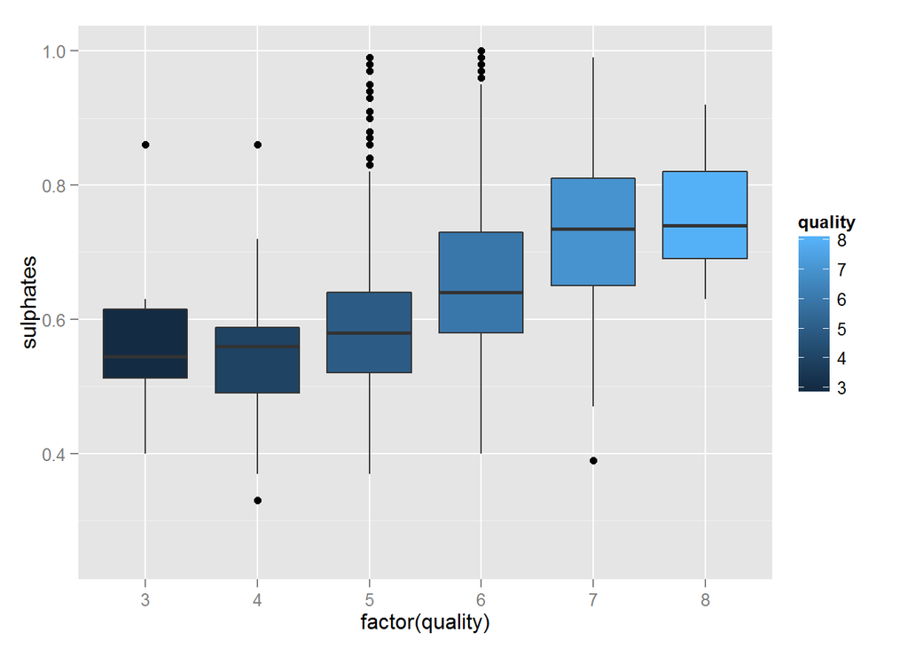

There is a slight trend in the relationship between *quality* and *sulphates*, that greater amount of *sulphates* tends to increase the quality, but not a lot. The correlation value between the two is 0.251.

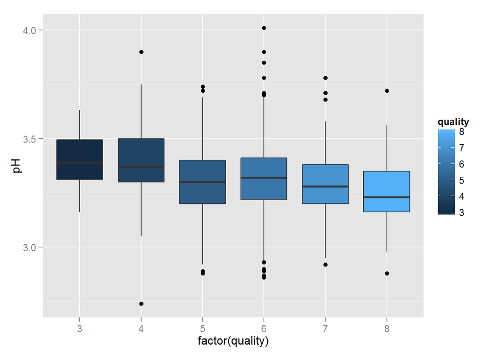

Relationship between *quality* and *pH*.

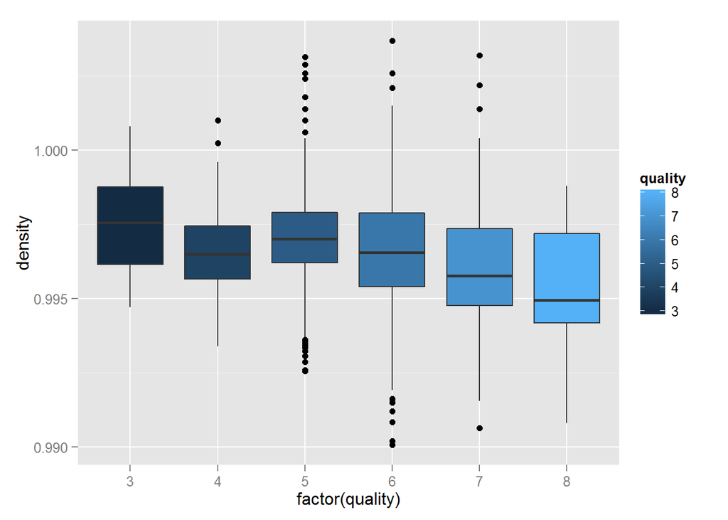

Relationship between *quality* and *density*.

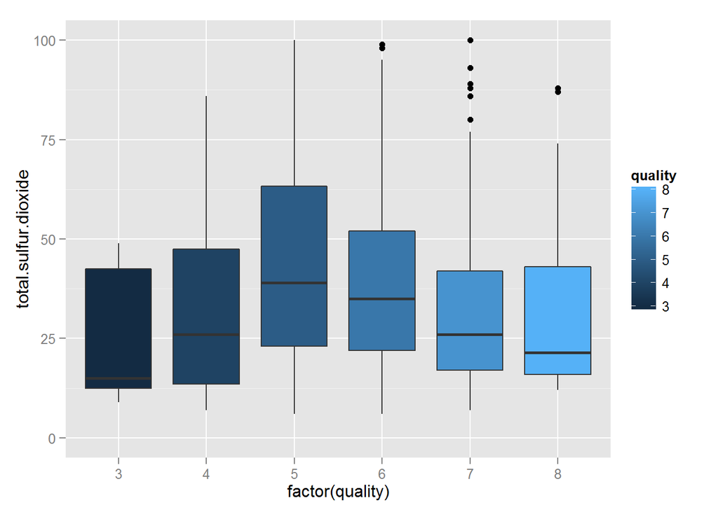

Relationship between *quality* and *total.sulfur.dioxide*.

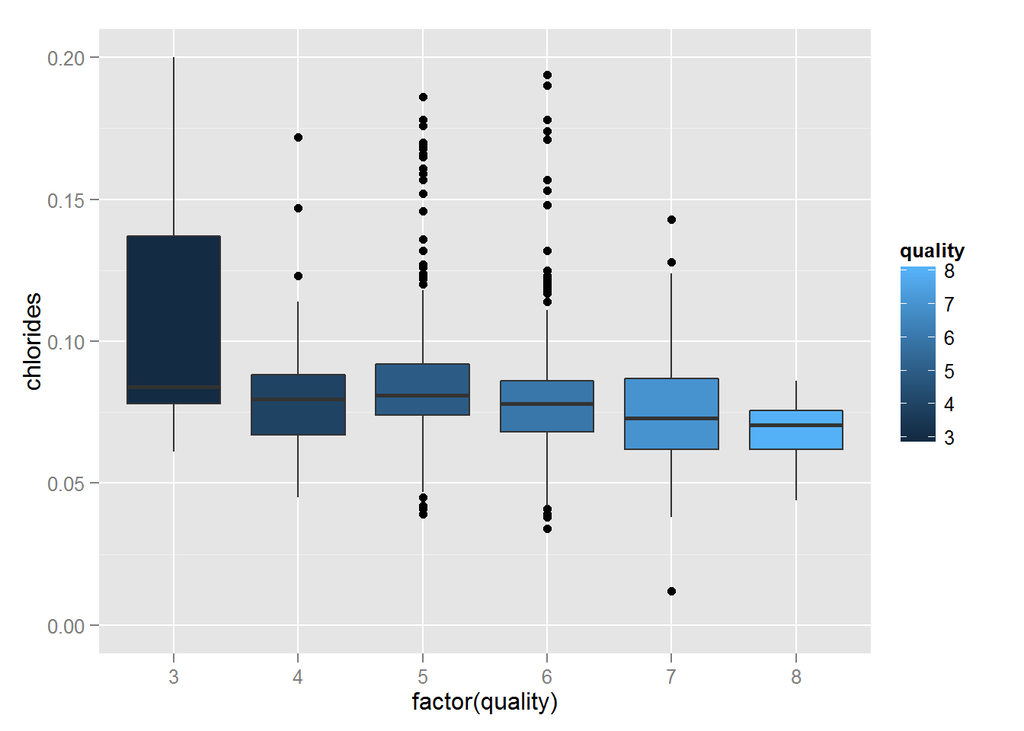

Relationship between *quality* and *chlorides*.

These figures do not reveal very interesting patterns.

By looking at the correlation matrix, I decide to plot the scatterplot between several variables that are correlated with each other, namely *fixed.acidity*, *volatile.acidity*, *citric.acid*, *density*, and *pH*.

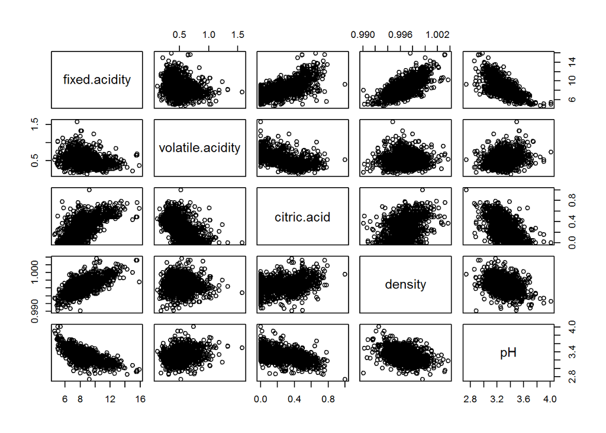

Also, there is a strong correlation between *free.sulfur.dioxide* and *total.sulfur.dioxide*.

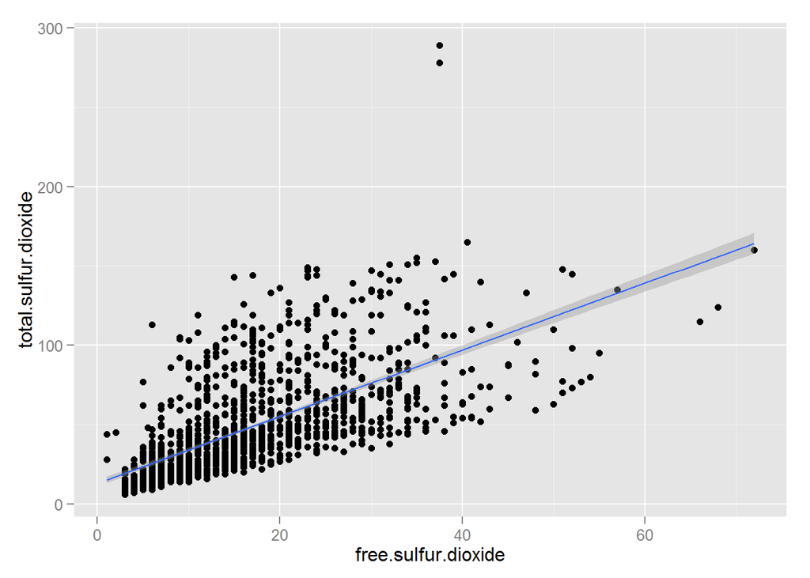

We can see *free.sulfur.dioxide* and *total.sulfur.dioxide* are positively correlated. The correlation value between the two is 0.668.

We look closer at some particular relationships between correlated features.

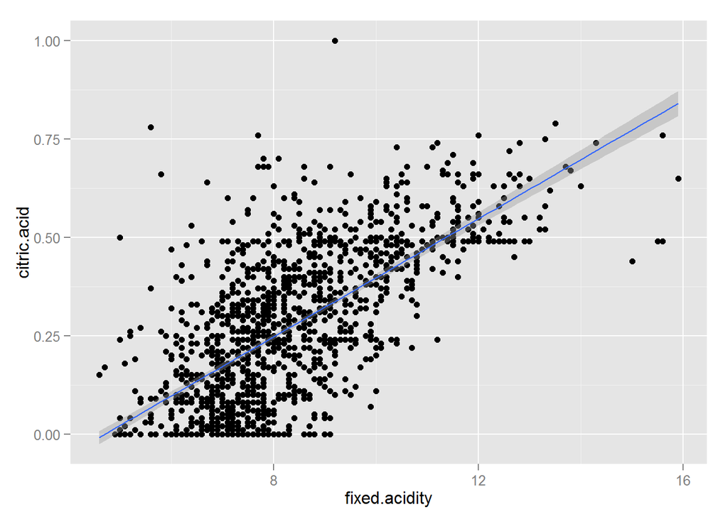

*fixed.acidity* and *citric.acid* are positively correlated. The correlation value between the two is 0.672.

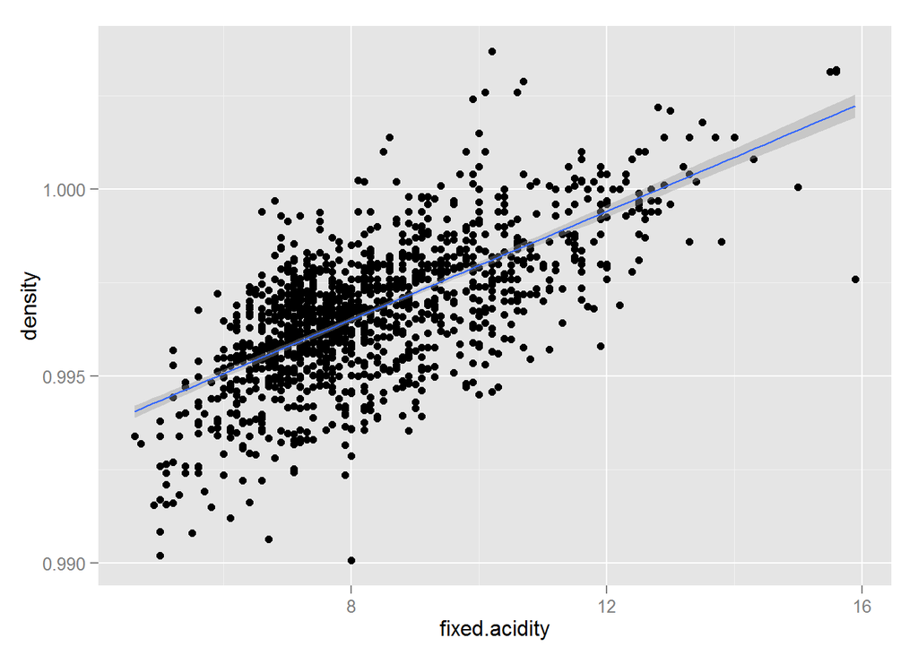

*fixed.acidity* and *density* are positively correlated. The correlation value between the two is 0.668.

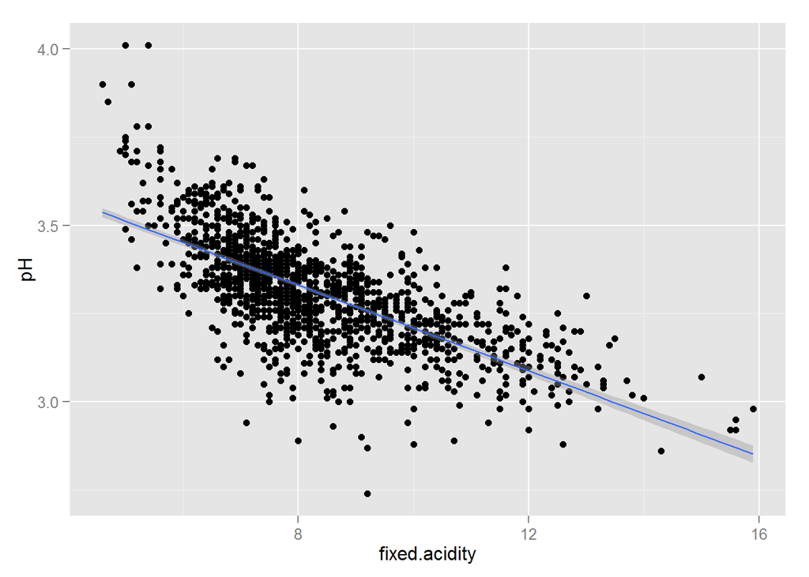

*fixed.acidity* and *pH* are negatively correlated. The correlation value between the two is -0.683.

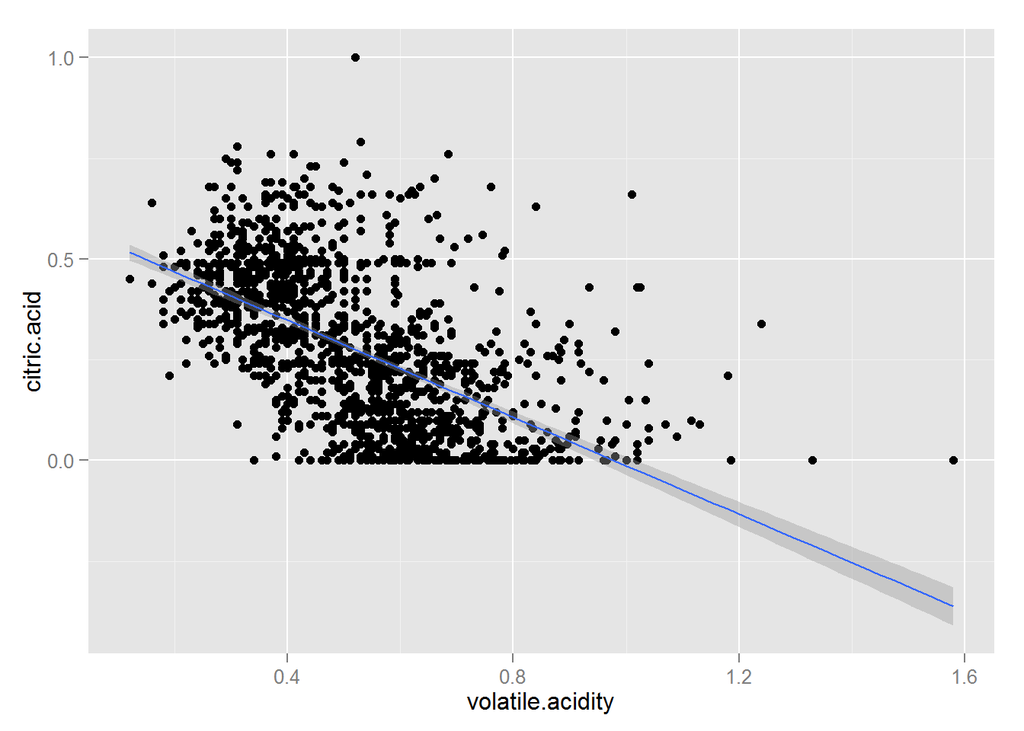

*volatile.acidity* and *citric.acid* are negatively correlated. The correlation value between the two is -0.552.

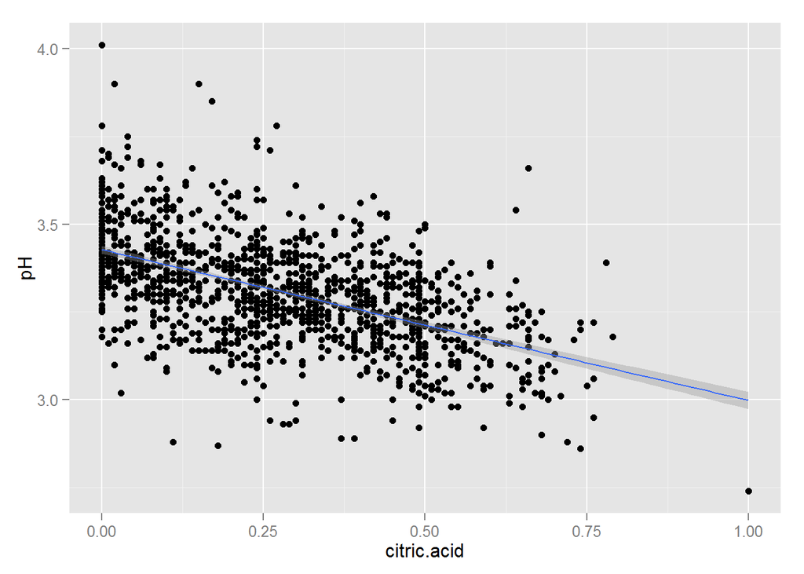

*pH* and *citric.acid* are negatively correlated. The correlation value between the two is -0.542.

# Bivariate Analysis

### Talk about some of the relationships you observed in this part of the investigation. How did the feature(s) of interest vary with other features in the dataset?

I notice that *quality* is somewhat correlation with *volatile.acidity* and *alcohol*. As we can see in the figures, higher percent alcohol content of the wine generally leads to higher quality, and lower amount of acetic acid in wine generally leads to higher quality. This makes sense since too high of levels of acetic acid can create an unpleasant, vinegar taste.

There is a slight trend in the relationship between *quality* and *sulphates*, that greater amount of *sulphates* tends to increase the quality, but not a lot.

Other relationships between *quality* and other features are not that interesting.

### What was the strongest relationship you found?

I think the strongest relationship I found is between *fixed.acidity* and *pH*, that more fixed acidity means lower pH value.

# Multivariate Plots Section

For multivariate plotting, I first want to investigate the distribution of *alcohol* and *volatile.acidity* at each level of *quality*.

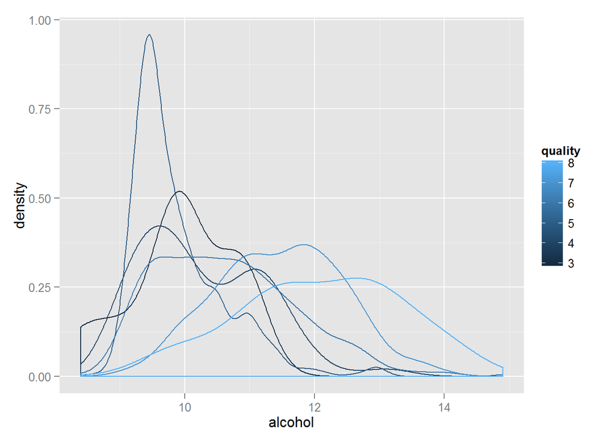

Good wines have skewed distributions towards high *alcohol* level, bad wines are pretty much centered around low *alcohol*.

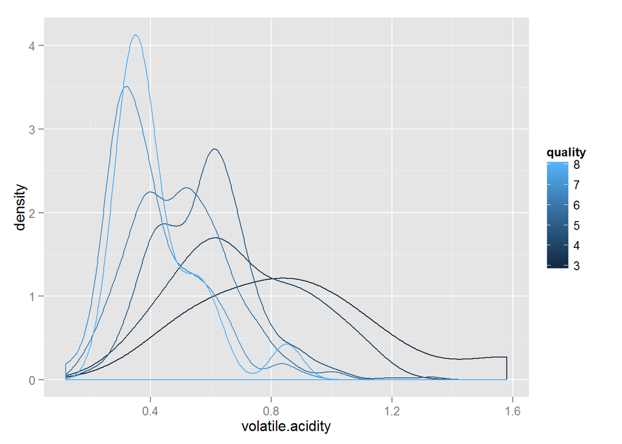

The good wines are centered around low *volatile.acidity* while the bad wines have high and low *volatile.acidity* values. However, high *volatile.acidity* values only lead to bad wine.

(Pay attention that the density on the y axis label does not mean the feature *density* but the probability density of the chosen feature.)